# Shruthi_AIML_ML_Project_2_Personal_Loan_Campaign (1)

```python
# importance of features in the tree building ( The importance of a feature is computed as the
# (normalized) total reduction of the criterion brought by that feature. It is also known as the Gini importance )

print(
    pd.DataFrame(
        estimator.feature_importances_, columns=["Imp"], index=X_train.columns
    ).sort_values(by="Imp", ascending=False)
)
```

```
                    Imp
Income         0.337681
Family         0.275581
Education_2    0.175687
Education_3    0.157286
CCAvg          0.042856
...                 ...
ZIPCode_92093  0.000000
ZIPCode_92084  0.000000
ZIPCode_92069  0.000000
ZIPCode_92068  0.000000
ZIPCode_93009  0.000000

[478 rows x 1 columns]
```

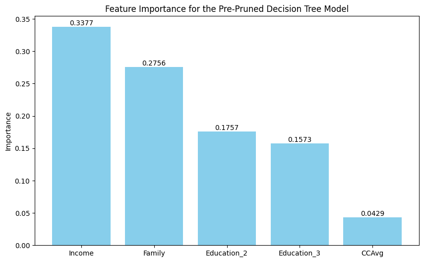

```python
import matplotlib.pyplot as plt

# Data for feature importance
features = ['Income', 'Family', 'Education_2', 'Education_3', 'CCAvg']
importance = [0.337681, 0.275581, 0.175687, 0.157286, 0.042856]

# Create bar graph
plt.figure(figsize=(10, 6))
bars = plt.bar(features, importance, color='skyblue')
plt.ylabel('Importance')
plt.title('Feature Importance for the Pre-Pruned Decision Tree Model')

# Add the importance values on top of the bars
for bar in bars:
    yval = bar.get_height()
    plt.text(bar.get_x() + bar.get_width()/2, yval, round(yval, 4), ha='center', va='bottom')

# Show the plot
plt.show()
```

[figure not shown]

```python
importances = estimator.feature_importances_
indices = np.argsort(importances)

plt.figure(figsize=(8, 8))
plt.title("Feature Importances")
plt.barh(range(len(indices)), importances[indices], color="violet", align="center")
plt.yticks(range(len(indices)), [feature_names[i] for i in indices])
plt.xlabel("Relative Importance")
plt.show()
```

**Checking performance on test data**

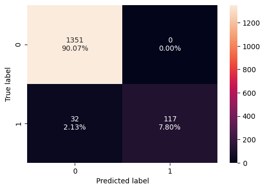

```python
confusion_matrix_sklearn(estimator, X_test, y_test)  # Complete the code to get the confusion matrix on test data
```

```python
decision_tree_tune_perf_test = model_performance_classification_sklearn(estimator, X_test, y_test) ## Complete the code to check performance on test data
decision_tree_tune_perf_test
```

|  | Accuracy | Recall | Precision | F1 |
| --- | --- | --- | --- | --- |
| 0 | 0.978667 | 0.785235 | 1.0 | 0.879699 |

```python
# Combine the metrics into a single DataFrame for easier comparison
comparison_df = pd.DataFrame({
    "Training Before Pruning": [1.0, 1.0, 1.0, 1.0],
    "Testing Before Pruning": [0.981333, 0.872483, 0.935252, 0.902778],
    "Training After Pre-Pruning": [0.987714, 0.873112, 0.996552, 0.930757],
    "Testing After Pre-Pruning": [0.978667, 0.785235, 1.0, 0.879699]
}, index=["Accuracy", "Recall", "Precision", "F1"])

# Now, to print the comparison table
print(comparison_df)
```

```
           Training Before Pruning  Testing Before Pruning  \
Accuracy                       1.0                0.981333
Recall                         1.0                0.872483
Precision                      1.0                0.935252
F1                             1.0                0.902778

           Training After Pre-Pruning  Testing After Pre-Pruning
Accuracy                     0.987714                   0.978667
Recall                       0.873112                   0.785235
Precision                    0.996552                   1.000000
F1                           0.930757                   0.879699
```

### Observations

Training Set Results: Confusion Matrix:

True Negatives: 3,168 False Positives: 1 False Negatives: 42 True Positives: 289 Performance Metrics:

Accuracy: 98.77% Recall: 87.31% Precision: 99.66% F1 Score: 93.08% The training set results indicate a high level of accuracy, precision, and F1 score. The model has almost perfect precision, which suggests it rarely makes a mistake when it predicts that someone will take a loan. However, there are more false negatives than false positives, meaning that the model misses some individuals who would take a loan (lower recall).

Testing Set Results: Confusion Matrix:

True Negatives: 1,351 False Positives: 0 False Negatives: 32 True Positives: 117 Performance Metrics:

Accuracy: 97.87% Recall: 78.52% Precision: 100% F1 Score: 87.97% The testing set results also show a high level of accuracy and an even higher precision than the training set, reaching a perfect score. However, recall has dropped, which means the model misses more actual loan takers when applied to the test set.

Comparison and Insights: Accuracy: Both training and testing results are very high, which is good but should be taken with caution due to the class imbalance in the data.

Recall: The model has a higher recall on the training set than on the test set. This suggests that the model might be slightly overfitting to the training data, capturing the nuances of the training set that don't generalize as well to the test set.

Precision: The model has very high precision on both sets, with a perfect precision score on the test set. This indicates that when the model predicts a customer will take a loan, it is almost always right.

F1 Score: The F1 score is high for both sets, which suggests a good balance between recall and precision. However, the slight drop in the F1 score on the test set compared to the training set could also indicate some overfitting.

Overfitting: The fact that the recall and F1 score are slightly lower on the test set might suggest that the model is overfitting to the training data, despite the precision remaining very high. It's managing to capture most of the nuances of the training set but is missing some of those in the test set.

Generalization: Despite the potential for overfitting, the model's performance on the test set is still very strong, suggesting it has learned generalizable patterns.

Business Implication: Given the objective of predicting personal loan uptake, the model's tendency to predict fewer false positives (at the cost of higher false negatives) could be acceptable depending on the cost associated with each type of error. If the cost of a false positive (offering a loan to someone who won't accept it) is high, this model would be beneficial. However, if the goal is to not miss any potential loan customers, the recall should be improved.

In conclusion, the model is performing well in terms of the metrics considered. But depending on the specific cost-benefit analysis (i.e., the cost of false positives versus false negatives), you may want to adjust the decision threshold to capture more true positives if increasing recall is a priority. Further investigation into the ROC curve and Precision-Recall curve could provide additional insights to refine the model's performance.

#### Cost-Complexity Pruning

```python
clf = DecisionTreeClassifier(random_state=1)
path = clf.cost_complexity_pruning_path(X_train, y_train)
ccp_alphas, impurities = path.ccp_alphas, path.impurities
```

```python
pd.DataFrame(path)
```

|  | ccp_alphas | impurities |
| --- | --- | --- |
| 0 | 0.000000 | 0.000000 |
| 1 | 0.000276 | 0.000552 |
| 2 | 0.000279 | 0.002224 |
| 3 | 0.000381 | 0.002605 |
| 4 | 0.000381 | 0.002986 |
| 5 | 0.000476 | 0.003462 |
| 6 | 0.000476 | 0.003938 |
| 7 | 0.000500 | 0.004438 |
| 8 | 0.000513 | 0.008031 |
| 9 | 0.000527 | 0.008558 |
| 10 | 0.000544 | 0.009103 |
| 11 | 0.000545 | 0.010739 |
| 12 | 0.000625 | 0.011364 |
| 13 | 0.000667 | 0.012031 |
| 14 | 0.000700 | 0.012731 |
| 15 | 0.000882 | 0.016260 |
| 16 | 0.000940 | 0.017200 |
| 17 | 0.001305 | 0.018505 |
| 18 | 0.001647 | 0.020153 |
| 19 | 0.002333 | 0.022486 |
| 20 | 0.002407 | 0.024893 |
| 21 | 0.003294 | 0.028187 |
| 22 | 0.006473 | 0.034659 |
| 23 | 0.025146 | 0.084951 |
| 24 | 0.039216 | 0.124167 |
| 25 | 0.047088 | 0.171255 |

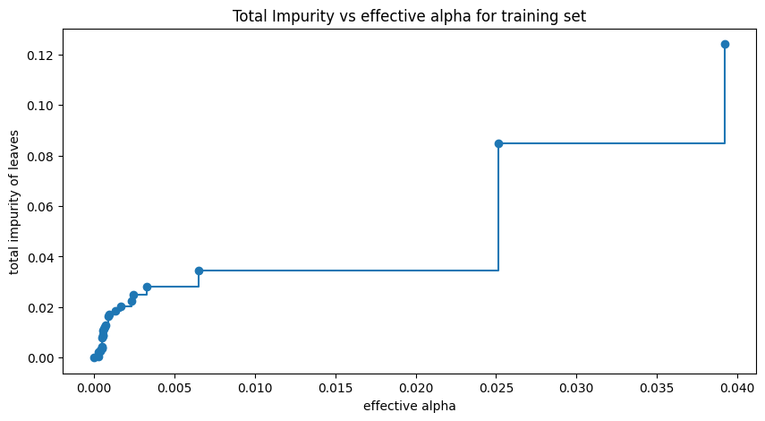

```python
fig, ax = plt.subplots(figsize=(10, 5))
ax.plot(ccp_alphas[:-1], impurities[:-1], marker="o", drawstyle="steps-post")
ax.set_xlabel("effective alpha")
ax.set_ylabel("total impurity of leaves")
ax.set_title("Total Impurity vs effective alpha for training set")
plt.show()
```

Next, we train a decision tree using effective alphas. The last value in `ccp_alphas` is the alpha value that prunes the whole tree, leaving the tree, `clfs[-1]`, with one node.

```python
clfs = []
for ccp_alpha in ccp_alphas:
    clf = DecisionTreeClassifier(random_state=1, ccp_alpha=ccp_alpha)
    clf.fit(X_train, y_train)     ## Complete the code to fit decision tree on training data
    clfs.append(clf)
print(
    "Number of nodes in the last tree is: {} with ccp_alpha: {}".format(
        clfs[-1].tree_.node_count, ccp_alphas[-1]
    )
)
```

```
Number of nodes in the last tree is: 1 with ccp_alpha: 0.04708834100596766
```

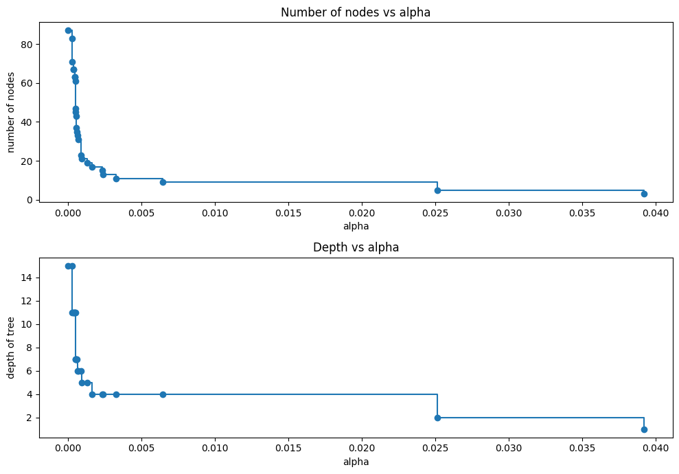

```python
clfs = clfs[:-1]
ccp_alphas = ccp_alphas[:-1]

node_counts = [clf.tree_.node_count for clf in clfs]
depth = [clf.tree_.max_depth for clf in clfs]
fig, ax = plt.subplots(2, 1, figsize=(10, 7))
ax[0].plot(ccp_alphas, node_counts, marker="o", drawstyle="steps-post")
ax[0].set_xlabel("alpha")
ax[0].set_ylabel("number of nodes")
ax[0].set_title("Number of nodes vs alpha")
ax[1].plot(ccp_alphas, depth, marker="o", drawstyle="steps-post")
ax[1].set_xlabel("alpha")
ax[1].set_ylabel("depth of tree")
ax[1].set_title("Depth vs alpha")
fig.tight_layout()
```

**Recall vs alpha for training and testing sets**

```python
recall_train = []
for clf in clfs:
    pred_train = clf.predict(X_train)
    values_train = recall_score(y_train, pred_train)
    recall_train.append(values_train)

recall_test = []
for clf in clfs:
    pred_test = clf.predict(X_test)
    values_test = recall_score(y_test, pred_test)
    recall_test.append(values_test)
```

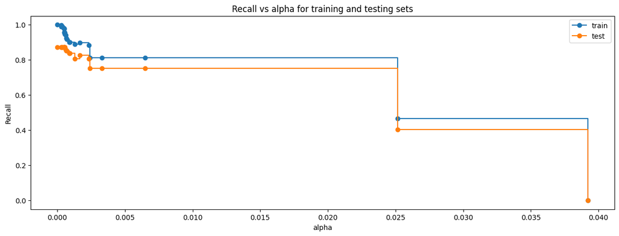

```python
fig, ax = plt.subplots(figsize=(15, 5))
ax.set_xlabel("alpha")
ax.set_ylabel("Recall")
ax.set_title("Recall vs alpha for training and testing sets")
ax.plot(ccp_alphas, recall_train, marker="o", label="train", drawstyle="steps-post")
ax.plot(ccp_alphas, recall_test, marker="o", label="test", drawstyle="steps-post")
ax.legend()
plt.show()
```

### Observations

Here’s a summary based on the plots and the data:

Total Impurity vs. Effective Alpha for Training Set: This plot shows how the total impurity of the leaves of the decision tree increases with higher values of ccp_alpha. Initially, as ccp_alpha increases, there is a slow increase in total impurity, indicating the model is getting rid of complexity without sacrificing much accuracy. However, there is a significant jump in impurity at higher alpha values, which suggests over-pruning.

Number of Nodes vs. Alpha: The plot shows a sharp decrease in the number of nodes as ccp_alpha increases at first, with the number stabilizing after a certain point. This suggests that most of the tree's complexity is reduced early in the pruning process.

Depth vs. Alpha: Similar to the number of nodes, the depth of the tree decreases rapidly with an increase in ccp_alpha initially and then flattens out, indicating that a less complex tree is achieved without drastically increasing alpha.

Table of Output for Cost Complexity Pruning: The table lists the ccp_alpha values alongside the corresponding total impurities. It looks like the impurity begins to rise more steeply at the later alpha values, which correspond to the points where the recall drops significantly in the Recall vs. Alpha plot.

The key takeaway from these observations is that there is a range of ccp_alpha values that effectively simplify the tree without a significant loss in recall. Choosing a ccp_alpha value within this range would give a pruned tree that balances complexity and performance well.

```python
index_best_model = np.argmax(recall_test)
best_model = clfs[index_best_model]
print(best_model)
print("Best model ccp_alpha:", best_model.ccp_alpha)
```

```
DecisionTreeClassifier(random_state=1)
Best model ccp_alpha: 0.0
```

#### Post-Purning

```python
estimator_2 = DecisionTreeClassifier(
    ccp_alpha=0.0, class_weight={0: 0.15, 1: 0.85}, random_state=1         ## Complete the code by adding the correct ccp_alpha value
)
estimator_2.fit(X_train, y_train)
```

```
DecisionTreeClassifier(class_weight={0: 0.15, 1: 0.85}, random_state=1)
```

**Checking performance on training data**

```python
confusion_matrix_sklearn(best_model, X_train, y_train) ## Complete the code to create confusion matrix for train data
```

[output not shown]

```python
decision_tree_tune_post_train = model_performance_classification_sklearn(best_model, X_train, y_train) ## Complete the code to check performance on train data
decision_tree_tune_post_train
```

|  | Accuracy | Recall | Precision | F1 |
| --- | --- | --- | --- | --- |
| 0 | 1.0 | 1.0 | 1.0 | 1.0 |

**Visualizing the Decision Tree**

[figure not shown]

```python
plt.figure(figsize=(10, 10))
out = tree.plot_tree(
    estimator_2,
    feature_names=feature_names,
    filled=True,
    fontsize=9,
    node_ids=False,
    class_names=None,
)
# below code will add arrows to the decision tree split if they are missing
for o in out:
    arrow = o.arrow_patch
    if arrow is not None:
        arrow.set_edgecolor("black")
        arrow.set_linewidth(1)
plt.show()
```

```python
# Text report showing the rules of a decision tree -

print(tree.export_text(estimator_2, feature_names=feature_names, show_weights=True))
```

```
|--- Income <= 98.50
|   |--- CCAvg <= 2.95
|   |   |--- weights: [374.10, 0.00] class: 0
|   |--- CCAvg >  2.95
|   |   |--- CD_Account <= 0.50
|   |   |   |--- CCAvg <= 3.95
|   |   |   |   |--- Income <= 81.50
|   |   |   |   |   |--- Age <= 36.50
|   |   |   |   |   |   |--- Family <= 3.50
|   |   |   |   |   |   |   |--- CCAvg <= 3.50
|   |   |   |   |   |   |   |   |--- Online <= 0.50
|   |   |   |   |   |   |   |   |   |--- weights: [0.00, 0.85] class: 1
|   |   |   |   |   |   |   |   |--- Online >  0.50
|   |   |   |   |   |   |   |   |   |--- weights: [0.00, 0.85] class: 1
|   |   |   |   |   |   |   |--- CCAvg >  3.50
|   |   |   |   |   |   |   |   |--- weights: [0.15, 0.00] class: 0
|   |   |   |   |   |   |--- Family >  3.50
|   |   |   |   |   |   |   |--- weights: [0.60, 0.00] class: 0
|   |   |   |   |   |--- Age >  36.50
|   |   |   |   |   |   |--- ZIPCode_91203 <= 0.50
|   |   |   |   |   |   |   |--- ZIPCode_93907 <= 0.50
|   |   |   |   |   |   |   |   |--- weights: [6.45, 0.00] class: 0
|   |   |   |   |   |   |   |--- ZIPCode_93907 >  0.50
|   |   |   |   |   |   |   |   |--- weights: [0.15, 0.00] class: 0
|   |   |   |   |   |   |--- ZIPCode_91203 >  0.50
|   |   |   |   |   |   |   |--- weights: [0.00, 0.85] class: 1
|   |   |   |   |--- Income >  81.50
|   |   |   |   |   |--- Mortgage <= 152.00
|   |   |   |   |   |   |--- Securities_Account <= 0.50
|   |   |   |   |   |   |   |--- CCAvg <= 3.05
|   |   |   |   |   |   |   |   |--- weights: [0.45, 0.00] class: 0
|   |   |   |   |   |   |   |--- CCAvg >  3.05
|   |   |   |   |   |   |   |   |--- ZIPCode_95616 <= 0.50
|   |   |   |   |   |   |   |   |   |--- Age <= 63.50
|   |   |   |   |   |   |   |   |   |   |--- ZIPCode_95521 <= 0.50
|   |   |   |   |   |   |   |   |   |   |   |--- truncated branch of depth 6
|   |   |   |   |   |   |   |   |   |   |--- ZIPCode_95521 >  0.50
|   |   |   |   |   |   |   |   |   |   |   |--- weights: [0.15, 0.00] class: 0
|   |   |   |   |   |   |   |   |   |--- Age >  63.50
|   |   |   |   |   |   |   |   |   |   |--- weights: [0.15, 0.00] class: 0
```

[output cut: 138 more lines]

```
|   |   |   |   |   |   |   |--- CCAvg <= 2.50
|   |   |   |   |   |   |   |   |--- weights: [0.30, 0.00] class: 0
|   |   |   |   |   |   |   |--- CCAvg >  2.50
|   |   |   |   |   |   |   |   |--- ZIPCode_90245 <= 0.50
|   |   |   |   |   |   |   |   |   |--- weights: [0.00, 5.10] class: 1
|   |   |   |   |   |   |   |   |--- ZIPCode_90245 >  0.50
|   |   |   |   |   |   |   |   |   |--- weights: [0.15, 0.00] class: 0
|   |   |   |   |   |   |--- Income >  116.50
|   |   |   |   |   |   |   |--- weights: [0.00, 130.90] class: 1
|   |   |   |   |   |--- ZIPCode_94105 >  0.50
|   |   |   |   |   |   |--- weights: [0.15, 0.00] class: 0
|   |   |   |   |--- Age >  66.00
|   |   |   |   |   |--- weights: [0.15, 0.00] class: 0
|   |   |   |--- ZIPCode_94608 >  0.50
|   |   |   |   |--- weights: [0.15, 0.00] class: 0
```